# D2SC ICMAs

# ICMA 10-8-2026

## Slides 15 - 16 (Include the following in your ICMA file)

```r
mpg |>
  ggplot(mapping = aes(y = hwy, x = displ, color = manufacturer)) +
  geom_point()
```

```r
mpg |>
  ggplot(aes(y = hwy, x = displ, color = manufacturer)) +
  geom_point()
#this runs the same thing just without 'mapping'
```

## Slide 19 (Include the following in your ICMA file)

```r
mpg |>
  ggplot(aes(y = hwy, x = displ, shape = manufacturer)) +
  geom_point()
#when you replace 'shape' with fill or alpha it's not a good use
```

[output not shown]

## Slide 42 (Include in ICMA)

Change the color of the line to something other than the default blue

```r
ggplot(mpg, aes(x = displ, y = hwy)) +
  geom_point(aes(color = class)) +
  geom_smooth(color='black') # aes mapping variables to properties - map color to this variable (black) - it draws a line then associates is to black. so just say (color ='black')
```

[output not shown]

#ICMA 10-13-2026

Add a `facet_wrap`

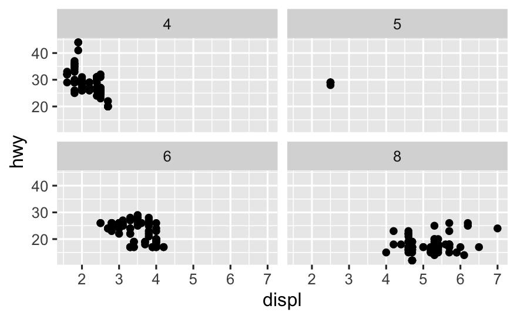

```r
mpg |>
  ggplot(aes(x = displ, y = hwy)) +
  geom_point() +
  facet_wrap(~cyl)
```

```r
#cyl is a variable in the mpg dataset
```

Set the number of columns to 4

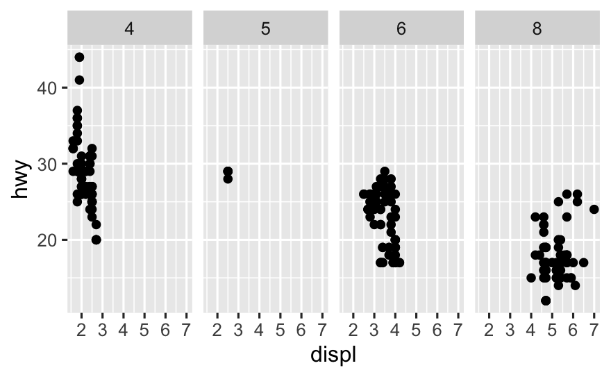

```r
mpg |>
  ggplot(aes(x = displ, y = hwy)) +
  geom_point() +
  facet_wrap(~cyl,ncol=4)
```

```r
#ncol=4 how many columns - took data and split it in 4 different plots
#more in range than compared with columns?
# lines things up can compare hwy easier
```

Set the number of rows to 4

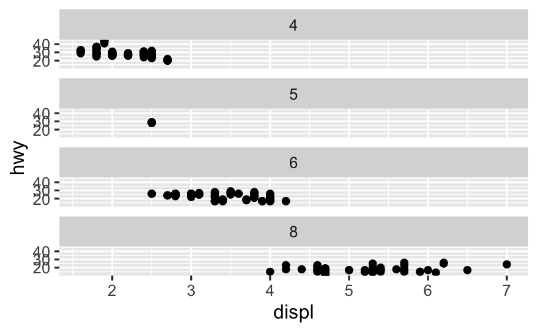

```r
mpg |>
  ggplot(aes(x = displ, y = hwy)) +
  geom_point() +
  facet_wrap(~cyl,nrow=4)
```

```r
#relationship by displ better with row
```

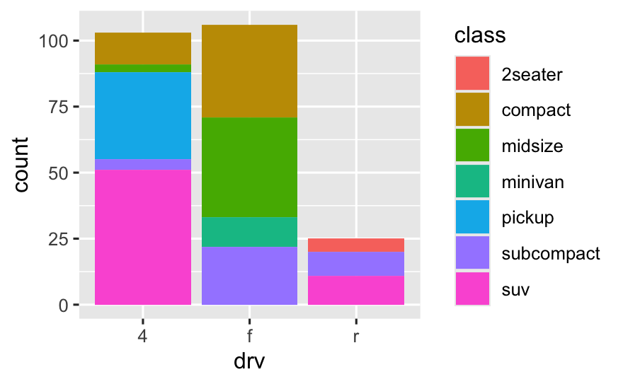

```r
ggplot(mpg,aes(x=drv,fill=class)) + #fill color to class
  geom_bar(position='stack')
```

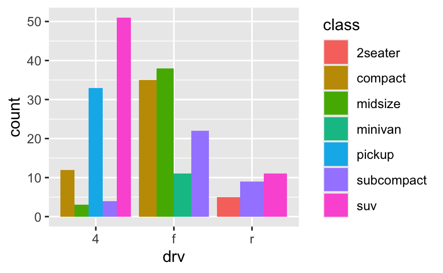

```r
ggplot(mpg,aes(x=drv,fill=class)) +
  geom_bar(position='dodge')
```

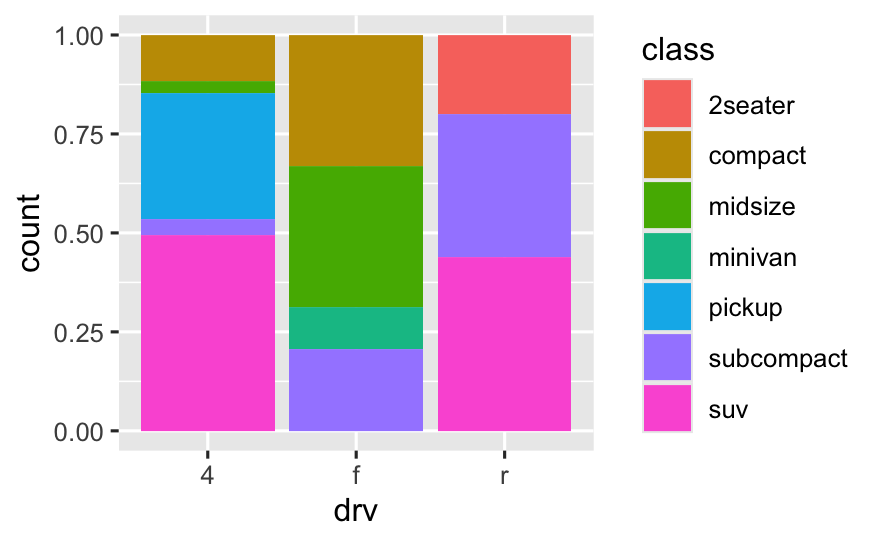

```r
#same underlying data only thing changed is position - one focuses on proportion. - compare to classes
ggplot(mpg,aes(x=drv,fill=class)) +
  geom_bar(position='fill') #gives proportional - fill entire column then fill. -- easier to compare between drv with classes
```

```r
# how we position to bar will tell us different information
```

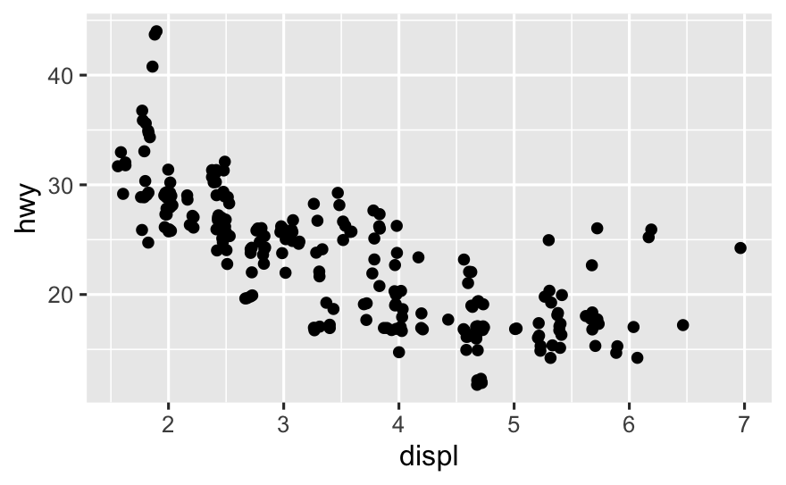

```r
ggplot(mpg, aes(x = displ, y = hwy)) +
  geom_point(position = 'jitter') #+- 0.05
```

```r
# get a better sense of the clusters - it slightly moves the position
```

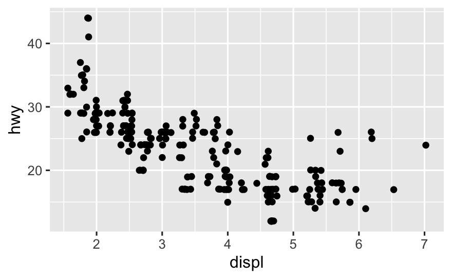

```r
ggplot(mpg, aes(x = displ, y = hwy)) +
  geom_jitter(width = 0.05, height= 0.05)
```

We want to add a facet using `facet_grid` that presents `drv` as rows and `cyl` as columns.

Do that below (if you need a hint, look at the supplement for Slide 14)

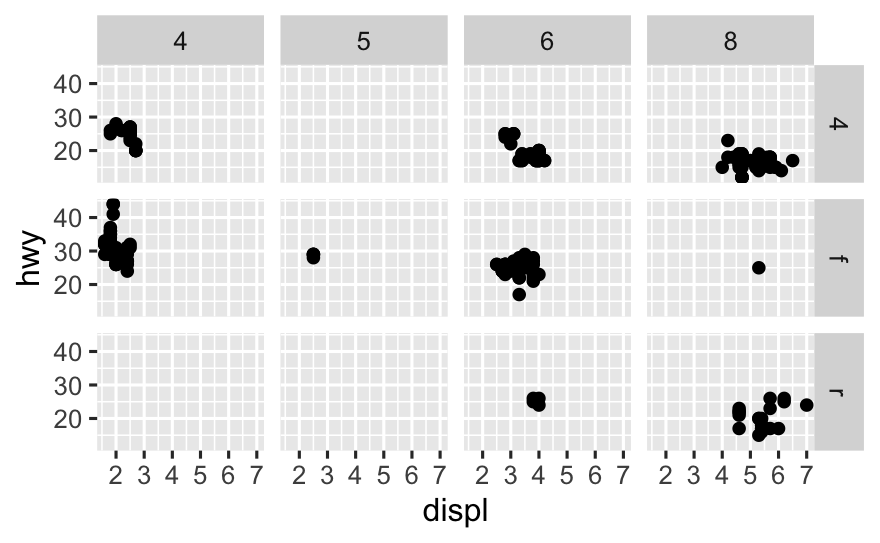

```r
ggplot(mpg, aes(x = displ, y = hwy)) +
  geom_point() +
  facet_grid(drv~cyl)
```

```r
# ~ = by
```

Let’s play with the x and y scales. First, call up the facet_grid documentation.

```r
?facet_grid
```

What does the “scales” option do and what values does it take?

We manipulate scales and we see how they react. there are different scales that change the way that the values are distributed and presented. the values that it takes are the y and the x .

Below, experiment with facet_grid option, `scales = "free_x"`, `scales = "free_y"`, and `scales = 'free'`, and `scales = 'fixed'`. Compare with the code chunk above without scales being specified

```r
ggplot(mpg, aes(x = displ, y = hwy)) +
  geom_point() +
  facet_grid(drv ~ cyl, scales = "free_x")
# some are not readuble- each x axis is different. there is more data here

ggplot(mpg, aes(x = displ, y = hwy)) +
  geom_point() +
  facet_grid(drv ~ cyl, scales = "free_y")

ggplot(mpg, aes(x = displ, y = hwy)) +
  geom_point() +
  facet_grid(drv ~ cyl,scales ="free")

ggplot(mpg, aes(x = displ, y = hwy)) +
  geom_point() +
  facet_grid(drv ~ cyl, scales = "fixed")
```

[output not shown]

#ICMA 10-15-2026

# ICMA Exercise: faceted histograms

Using the `diamonds` dataset, create 2 plots.

1. A plot showing a histogram of diamond price
2. A plot showing a histogram of diamond price, **faceted** by color and cut

Choose a suitable bin width for your histogram(s). What influenced your choice?

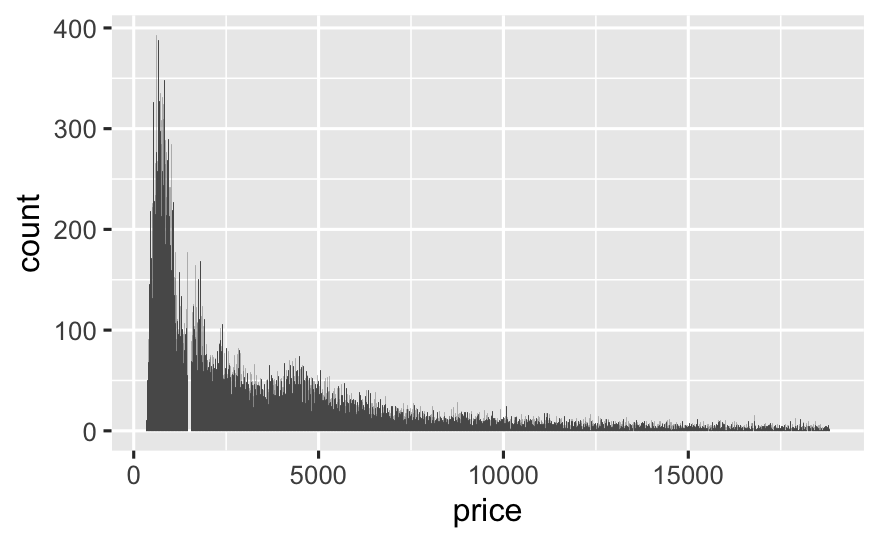

```r
ggplot(diamonds, aes(x = price)) +
  geom_histogram(binwidth = 10)
```

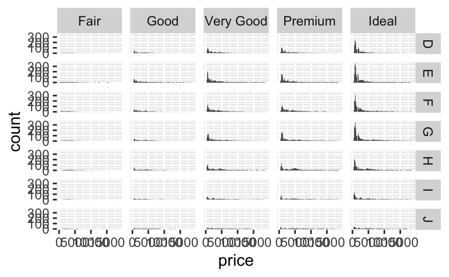

```r
ggplot(diamonds, aes(x = price)) +
  geom_histogram(binwidth = 100) +
  facet_grid(color~cut)
```

# ICMA Exercise: two variables

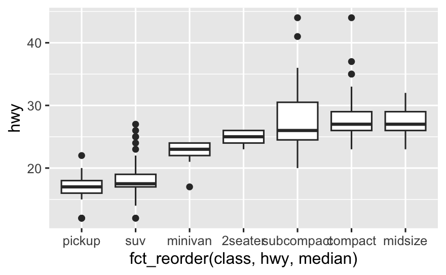

```r
mpg |>
  ggplot(aes(x = fct_reorder(class, hwy, median),
             y = hwy)) +
  geom_boxplot()
```

# ICMA Exercise: histograms vs. boxplots

Compare and contrast the two plots. What kind of information is highlighted by each? What kind of information is highlighted by both?

```r
ggplot(diamonds, aes(x = carat)) +
  geom_histogram(binwidth = 0.1)
```

[output not shown]

```r
diamonds |>
  ggplot(aes(x = carat)) +
  geom_boxplot(outlier.colour = 'red')
```

[output not shown]

#ICMA 10-20-2026 # ICMA Exercise (last class): two variables

Using the `mpg` dataset plot a frequency polygon of the `hwy` variable, with the `class` variable mapped to the color aesthetic

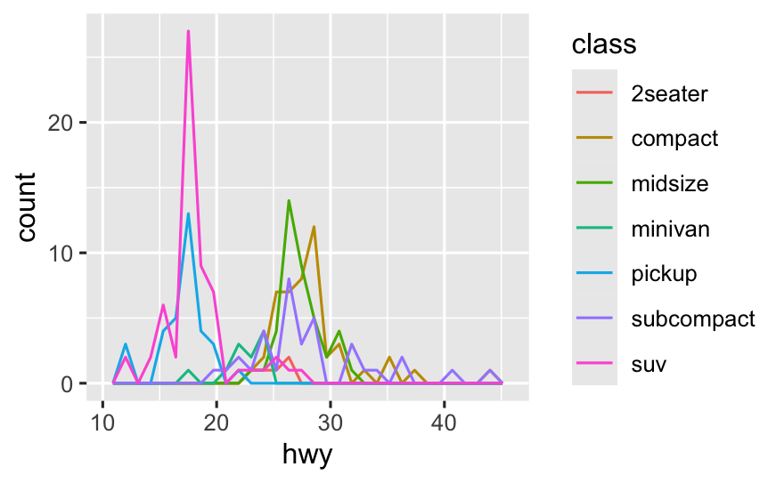

```r
ggplot(mpg, aes(x = hwy))+
  geom_freqpoly(aes(color = class))
```

# ICMA Exercise (last class): histograms vs. boxplots

Below I have plotted a histograms and boxplots of the same data. Both plots show the variation of the `carat` variable from the `diamonds` data set.

Compare and contrast the two plots. What kind of information is highlighted by each? What kind of information is highlighted by both?

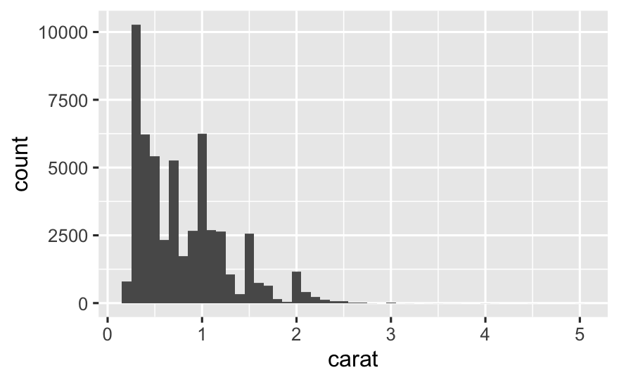

```r
ggplot(diamonds, aes(x = carat)) +
  geom_histogram(binwidth = 0.1)
```

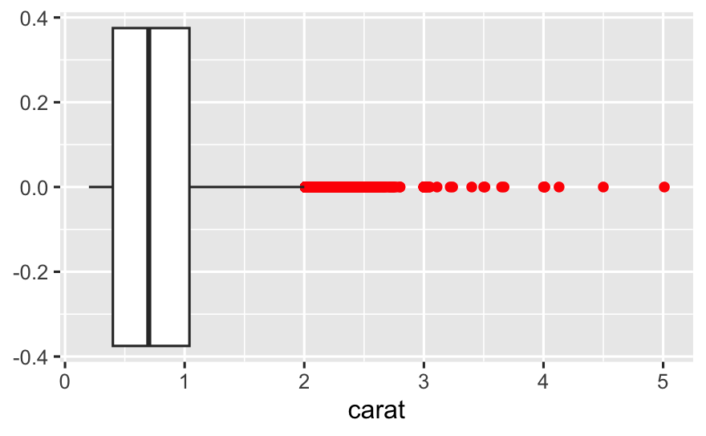

```r
diamonds |>
  ggplot(aes(x = carat)) +
  geom_boxplot(outlier.colour = 'red')
```

#ICMA 10-22-2026 ``